# YouTube Analysis

## Exploring YouTube Channel Performance: A Comprehensive Data Analysis

### This project is a descriptive and exploratory data analysis (EDA), focusing on uncovering trends, correlations, and patterns within YouTube channel data.

#### Objective:

The primary objective of this analysis was to explore relationships between various metrics and to identify patterns that contribute to the success of YouTube channels.

#### Data Source:

https://www.kaggle.com/datasets/nelgiriyewithana/global-youtube-statistics-2023

#### Data Cleaning:

The dataset required significant preprocessing to handle missing values, non-standard date formats, and non-numeric characters in key columns like subscriber counts. This step was crucial in ensuring the accuracy and reliability of the subsequent analysis.

#### Key Research Questions:

1.What are the key factors affecting the success of a YouTube channel in terms of views and subscriber growth? Is there a relationship between the number of subscribers and video views, and how significant is this correlation?

2.Which content categories generally achieve better performance? How do different metrics, such as content categories and location, influence a video's overall success?

3.What patterns or trends can be observed in the geographic distribution of viewers and subscribers?

4.What are the top ten channels with the highest number of subscribers and views?

5.How has YouTube channel growth evolved over the years?

```python
import pandas as pd
from datetime import datetime
import numpy as np
import matplotlib.pyplot as plt
import seaborn as sns
```

```python
# Load the dataset
df = pd.read_csv('YouTube Statistics.csv', on_bad_lines='skip' )
df.head()
```

|  | rank | Youtuber | subscribers | video views | category | Title | uploads | Country | Abbreviation | channel_type | ... | subscribers_for_last_30_days | created_year | created_month | created_date | Gross tertiary education enrollment (%) | Population | Unemployment rate | Urban_population | Latitude | Longitude |
| --- | --- | --- | --- | --- | --- | --- | --- | --- | --- | --- | --- | --- | --- | --- | --- | --- | --- | --- | --- | --- | --- |
| 0 | 1 | T-Series | 245,000,000 | 2.280000e+11 | Music | T-Series | 20082 | India | IN | Music | ... | 2000000.0 | 2006.0 | Mar | 13.0 | 28.1 | 1.366418e+09 | 5.36 | 471031528.0 | 20.593684 | 78.962880 |
| 1 | 2 | YouTube Movies | 170,000,000 | 0.000000e+00 | Film & Animation | youtubemovies | 1 | United States | US | Games | ... | NaN | 2006.0 | Mar | 5.0 | 88.2 | 3.282395e+08 | 14.70 | 270663028.0 | 37.090240 | -95.712891 |
| 2 | 3 | MrBeast | 166,000,000 | 2.836884e+10 | Entertainment | MrBeast | 741 | United States | US | Entertainment | ... | 8000000.0 | 2012.0 | Feb | 20.0 | 88.2 | 3.282395e+08 | 14.70 | 270663028.0 | 37.090240 | -95.712891 |
| 3 | 4 | Cocomelon - Nursery Rhymes | 162,000,000 | 1.640000e+11 | Education | Cocomelon - Nursery Rhymes | 966 | United States | US | Education | ... | 1000000.0 | 2006.0 | Sep | 1.0 | 88.2 | 3.282395e+08 | 14.70 | 270663028.0 | 37.090240 | -95.712891 |
| 4 | 5 | SET India | 159,000,000 | 1.480000e+11 | Shows | SET India | 116536 | India | IN | Entertainment | ... | 1000000.0 | 2006.0 | Sep | 20.0 | 28.1 | 1.366418e+09 | 5.36 | 471031528.0 | 20.593684 | 78.962880 |

5 rows × 28 columns

### Data Cleaning

```python
# Check for duplicates
duplicates = df.duplicated()
print(f'Total duplicates in the dataset: {duplicates.sum()}')

# Remove duplicates
df_no_duplicates = df.drop_duplicates()
```

```
Total duplicates in the dataset: 0
```

```python
# Count missing values in each column
missing_values = df.isnull().sum()
print(missing_values)

# Count missing values in the entire dataset
total_missing = df.isnull().sum().sum()
print(f'Total missing values in the dataset: {total_missing}')
```

```
rank                                         0
Youtuber                                     0
subscribers                                  0
video views                                  0
category                                    46
Title                                        0
uploads                                      0
Country                                    122
Abbreviation                               122
channel_type                                30
video_views_rank                             1
country_rank                               116
channel_type_rank                           33
video_views_for_the_last_30_days            56
lowest_monthly_earnings                      0
highest_monthly_earnings                     0
lowest_yearly_earnings                       0
highest_yearly_earnings                      0
subscribers_for_last_30_days               337
created_year                                 5
created_month                                5
created_date                                 5
Gross tertiary education enrollment (%)    123
Population                                 123
Unemployment rate                          123
Urban_population                           123
Latitude                                   123
Longitude                                  123
dtype: int64
Total missing values in the dataset: 1616
```

```python
# Remove rows where 'Category' or 'Country' is NaN (blank)
df_cleaned = df.dropna(subset=['category', 'Country'])

# Save the cleaned DataFrame to a new CSV file
df_cleaned.to_csv('cleaned_dataset.csv', index=False)
```

```python
# Count missing values in each column
missing_values = df_cleaned.isnull().sum()
print(missing_values)
# Find the number of rows
num_rows = df_cleaned.shape[0]
print(f'The dataset has {num_rows} rows.')
```

```
rank                                         0
Youtuber                                     0
subscribers                                  0
video views                                  0
category                                     0
Title                                        0
uploads                                      0
Country                                      0
Abbreviation                                 0
channel_type                                 7
video_views_rank                             1
country_rank                                 1
channel_type_rank                            9
video_views_for_the_last_30_days            22
lowest_monthly_earnings                      0
highest_monthly_earnings                     0
lowest_yearly_earnings                       0
highest_yearly_earnings                      0
subscribers_for_last_30_days               271
created_year                                 3
created_month                                3
created_date                                 3
Gross tertiary education enrollment (%)      1
Population                                   1
Unemployment rate                            1
Urban_population                             1
Latitude                                     1
Longitude                                    1
dtype: int64
The dataset has 834 rows.
```

```python
df_cleaned = df_cleaned.dropna(subset=['subscribers'])
```

```python
# Define a function to convert values to strings
def to_string(x):
    try:
        return str(x)
    except Exception as e:
        return ''

# Clean the column by removing non-numeric characters
df_cleaned['subscribers'] = df_cleaned['subscribers'].apply(to_string)
df_cleaned['subscribers'] = df_cleaned['subscribers'].str.replace(',', '')

# Convert to float
df_cleaned['subscribers'] = df_cleaned['subscribers'].astype(float)
```

```python
print(df_cleaned['subscribers'].dtype)  # Check current dtype
print(df_cleaned['subscribers'].head())  # Inspect the first few rows
```

```
float64
0    245000000.0
1    170000000.0
2    166000000.0
3    162000000.0
4    159000000.0
Name: subscribers, dtype: float64
```

```python
num_rows = df_cleaned.shape[0]
print(f'The dataset has {num_rows} rows.')
```

```
The dataset has 834 rows.
```

```python
print(df_cleaned.dtypes)
```

```
rank                                         int64
Youtuber                                    object
subscribers                                float64
video views                                float64
category                                    object
Title                                       object
uploads                                      int64
Country                                     object
Abbreviation                                object
channel_type                                object
video_views_rank                           float64
country_rank                               float64
channel_type_rank                          float64
video_views_for_the_last_30_days           float64
lowest_monthly_earnings                    float64
highest_monthly_earnings                   float64
lowest_yearly_earnings                     float64
highest_yearly_earnings                    float64
subscribers_for_last_30_days               float64
created_year                               float64
created_month                               object
created_date                               float64
Gross tertiary education enrollment (%)    float64
Population                                 float64
Unemployment rate                          float64
Urban_population                           float64
Latitude                                   float64
Longitude                                  float64
dtype: object
```

## 1. Top 10 YouTubers by Subscribers

**Identify and visualize the top 10 YouTubers with the highest number of subscribers**

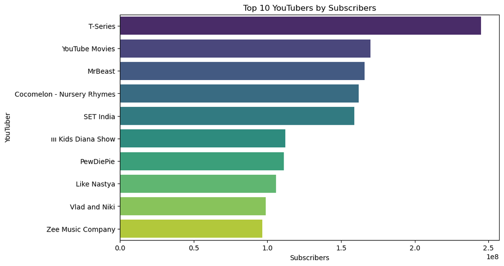

```python
#Get the top 10 YouTubers by subscribers
top_10_subs = df_cleaned.sort_values(by='subscribers', ascending=False).head(10)

# Plot the Data
if top_10_subs.empty:
    print("No data available to plot.")
else:
    plt.figure(figsize=(10, 6))
    sns.barplot(x='subscribers', y='Youtuber', data=top_10_subs, palette='viridis')
    plt.title('Top 10 YouTubers by Subscribers')
    plt.xlabel('Subscribers')
    plt.ylabel('YouTuber')
    plt.show()
```

T-Series leads significantly with the highest number of subscribers, followed by YouTube Movies and MrBeast. This indicates the dominance of music and entertainment content on the platform.

## 2. Category Distribution

**Analyze the distribution of YouTubers across different categories**

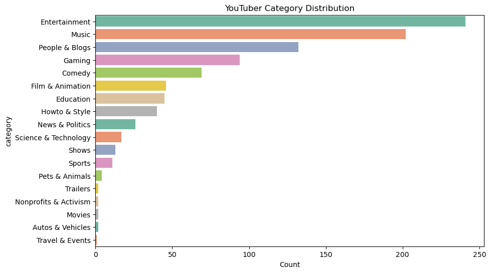

```python
plt.figure(figsize=(10, 6))
sns.countplot(y='category', data=df, palette='Set2', order=df['category'].value_counts().index)
plt.title('YouTuber Category Distribution')
plt.xlabel('Count')
plt.ylabel('category')
plt.show()
```

The most popular categories are Entertainment, Music, and People & Blogs, showing a strong viewer preference for diverse and engaging content. Gaming and Comedy also have significant representation, highlighting the popularity of these genres.

## 3. Correlation Between Subscribers and Video Views

**Find out the strength of the correlation between the number of subscribers and total video views**

```python
df_cleaned = df_cleaned.dropna(subset=['video views'])
```

```python
# Define a function to convert values to strings
def to_string(x):
    try:
        return str(x)
    except Exception as e:
        return ''

# Clean the column by removing non-numeric characters
df_cleaned['video views'] = df_cleaned['video views'].apply(to_string)
df_cleaned['video views'] = df_cleaned['video views'].str.replace(',', '')

# Convert to float
df_cleaned['video views'] = df_cleaned['video views'].astype(float)
```

```
Correlation between Subscribers and Video Views: 0.79
```

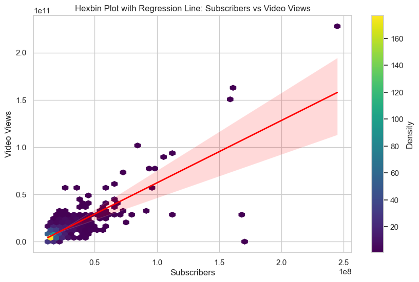

```python
correlation = df_cleaned['subscribers'].corr(df_cleaned['video views'])
print(f'Correlation between Subscribers and Video Views: {correlation:.2f}')

# Set the aesthetic style of the plots
sns.set(style="whitegrid")

# Create a hexbin plot with a regression line
plt.figure(figsize=(10, 6))

# Generate the hexbin plot
plt.hexbin(df_cleaned['subscribers'], df_cleaned['video views'], gridsize=50, cmap='viridis', mincnt=1)

# Overlay a regression line using seaborn's regplot
sns.regplot(x='subscribers', y='video views', data=df_cleaned, scatter=False, color='red', line_kws={"linewidth": 2})

# Add labels and title
plt.xlabel('Subscribers')
plt.ylabel('Video Views')
plt.title('Hexbin Plot with Regression Line: Subscribers vs Video Views')

# Add a color bar to show the density of data points
cb = plt.colorbar(label='Density')

plt.show()
```

There is a strong positive correlation (0.79) between the number of subscribers and video views, suggesting that channels with more subscribers tend to garner more views. However, outliers indicate that some channels with fewer subscribers still achieve high video views, possibly due to viral content or high engagement.

## 4. Earnings Estimations

**Comparision between the highest and lowest yearly earnings for different YouTube channels**

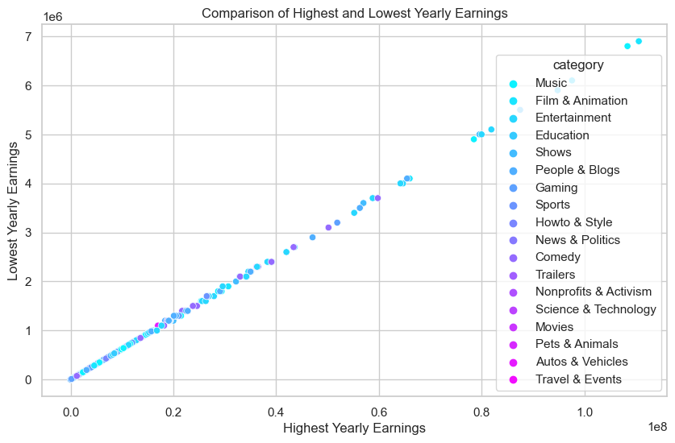

```python
plt.figure(figsize=(10, 6))
sns.scatterplot(x='highest_yearly_earnings', y='lowest_yearly_earnings', data=df, hue='category', palette='cool')
plt.title('Comparison of Highest and Lowest Yearly Earnings')
plt.xlabel('Highest Yearly Earnings')
plt.ylabel('Lowest Yearly Earnings')
plt.show()
```

This scatter plot compares the highest and lowest yearly earnings across various categories. The positive correlation suggests that categories with higher top earners also have higher minimum earners. Categories such as "Music," "Entertainment," and "Gaming" stand out, indicating they generate substantial revenue even at the lower end.

## 5. Geographic Analysis

**Visualizes the top 10 countries with the most YouTubers**

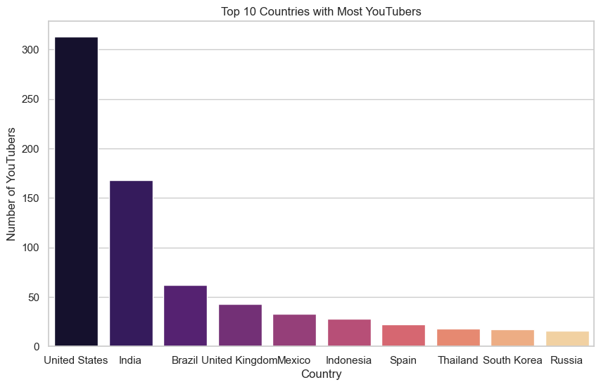

```python
top_countries = df['Country'].value_counts().head(10)
plt.figure(figsize=(10, 6))
sns.barplot(x=top_countries.index, y=top_countries.values, palette='magma')
plt.title('Top 10 Countries with Most YouTubers')
plt.ylabel('Number of YouTubers')
plt.xlabel('Country')
plt.show()
```

The USA dominates the YouTube content creator landscape, followed by emerging markets like India and Brazil, which show significant but smaller presences. This distribution highlights the platform's global reach and indicates growth opportunities in these rapidly expanding regions.

## 6. YouTube Channel Growth Over Time

**Analyze the growth of YouTube channels over time based on their creation dates**

```python
# Convert month names to numeric values
month_mapping = {'Jan': 1, 'Feb': 2, 'Mar': 3, 'Apr': 4, 'May': 5,
                  'Jun': 6, 'Jul': 7, 'Aug': 8, 'Sep': 9, 'Oct': 10,
                  'Nov': 11, 'Dec': 12}

# Apply the mapping to the 'created_month' column
df_cleaned['created_month'] = df_cleaned['created_month'].map(month_mapping)
```

```python
num_rows = df_cleaned.shape[0]
print(f'The dataset has {num_rows} rows.')
```

```
The dataset has 834 rows.
```

```python
# Convert columns to numeric values
df_cleaned['created_year'] = pd.to_numeric(df_cleaned['created_year'], errors='coerce')
df_cleaned['created_month'] = pd.to_numeric(df_cleaned['created_month'], errors='coerce')
df_cleaned['created_date'] = pd.to_numeric(df_cleaned['created_date'])
```

```python
print(df_cleaned[['created_year', 'created_month', 'created_date']])
```

```
     created_year  created_month  created_date
0          2006.0            3.0          13.0
1          2006.0            3.0           5.0
2          2012.0            2.0          20.0
3          2006.0            9.0           1.0
4          2006.0            9.0          20.0
..            ...            ...           ...
989        2012.0            1.0          17.0
990        2017.0            2.0          12.0
991        2018.0            9.0          14.0
993        2012.0            5.0           9.0
994        2017.0            8.0           1.0

[834 rows x 3 columns]
```

```python
print(df_cleaned['created_year'].dtype)
```

```
float64
```

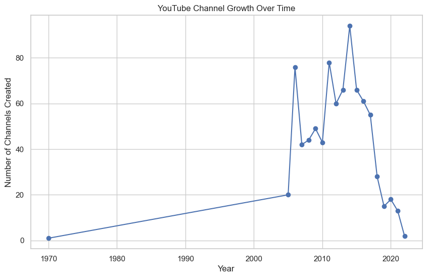

```python
# Fill missing values in 'created_date' with default value (1)
df_cleaned['created_date'].fillna(1, inplace=True)

# Create a datetime column using valid year, month, and date
def create_datetime(year, month, day):
    try:
        # Return datetime object
        return datetime(year=int(year), month=int(month), day=int(day))
    except (ValueError, TypeError):
        # Return Not a Time if there's an error
        return pd.NaT

# Apply the function to create a datetime column
df_cleaned['created_date'] = df_cleaned.apply(
    lambda row: create_datetime(row['created_year'], row['created_month'], row['created_date']),
    axis=1
)

# Extract year for grouping, only if created_date is not NaT
df_cleaned['year'] = df_cleaned['created_date'].dt.year

# Group by the year column and count the number of entries
channel_growth = df_cleaned.groupby('year').size()

# Plotting the channel growth over time
plt.figure(figsize=(10, 6))
channel_growth.plot(kind='line', marker='o', color='b')
plt.title('YouTube Channel Growth Over Time')
plt.xlabel('Year')
plt.ylabel('Number of Channels Created')
plt.grid(True)
plt.show()
```

This line graph tracks the number of YouTube channels created over time. There's a significant growth in the number of channels post-2005, coinciding with YouTube's rise in popularity. The peak around 2010-2015 suggests a period of rapid platform adoption, followed by a decline, possibly indicating market saturation or changes in platform policies.

## 7. Top 10 YouTubers by Video Views

**Identification the top YouTubers based on video views and visualizes it with a bar plot**

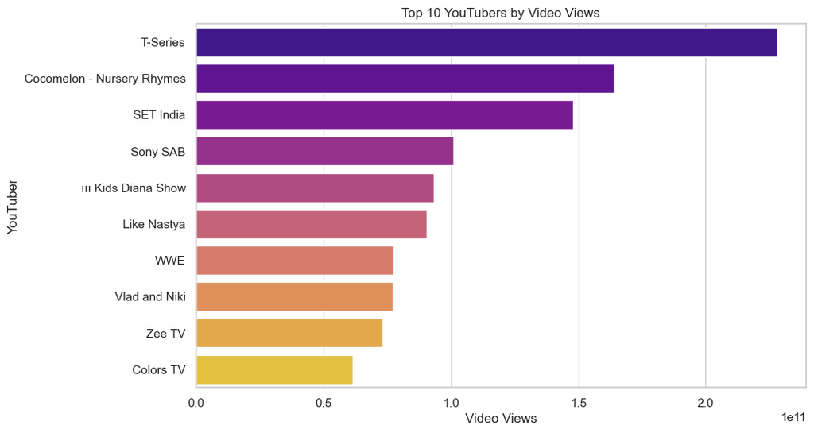

```python
top_10_views = df.sort_values(by='video views', ascending=False).head(10)
plt.figure(figsize=(10, 6))
sns.barplot(x='video views', y='Youtuber', data=top_10_views, palette='plasma')
plt.title('Top 10 YouTubers by Video Views')
plt.xlabel('Video Views')
plt.ylabel('YouTuber')
plt.show()
```

This bar chart highlights the top 10 YouTubers by video views. T-Series leads by a wide margin, followed by channels like Cocomelon and SET India. The dominance of content related to music, children’s entertainment, and television shows indicates that these genres are highly popular and attract significant viewership on YouTube